# Investigating The 2021 Household Census Conducted In England

This is a modified data snapshot from houehold 2021 census in England

Author

Prince Onuekwa(2225363)

Published

November 10, 2023

# 1 **Introduction**

In the UK census is carried out every 10 years by the office of the National statistic to have snapshots of the society to simplify the planning of education, roads , healthcare etc.( [visit](https://www.ons.gov.uk/census/aboutcensus/aboutthecensus#:~:text=The%20census%20is%20undertaken%20by,detailed%20snapshot%20of%20our%20society) to read more )

In this work , we would highlight different features and investigate how they relate to one another based on a modified snapshot of data collected during 2021 household census conducted in England.This article will be making use of (Wickham et al. 2019)**`tidyverse`** packages such as (Wickham, Hester, and Bryan 2023)**`readr`** , (Wickham 2016a)**`ggplots`**, (Wickham et al. 2023)**`dplyr`** (Arnold 2021) **`ggthemes`** to produce appropriate visuals and interpret insights from the data set. For more knowledge on tidyverse, I recommend R for Data Science( [Wickham, Hadley, and Garrett Grolemund. 2017](https://r4ds.had.co.nz/))

# 2 The Data

The data was collected from people living in different households in England 2021 and it contains different **variables** but our main concern for this article will be focused on the `Age`, `Marital_Status`, `Females`, `Highest Ed` and `Income`. The below table shows the first 7 rows of the data set where `Age` denotes ages of people in `dbl` , `Marital_status` refers to marital status which is either `Married`, `Divorced`, `Single` , `Windowed` or `Separated` in `chr` , `Females` which indicates whether or not the individual has identified as female (`0` = yes, `1`= No) in `dbl`, `Eth` for Ethnicity which consists of `Asian` , `Black`, `White`, `Hispanic`, `Other` in `chr` and `Highest Ed` which refers to the highest education level that consists of `Bachelor Degree,` `Masters or higher`, `Secondary School` , `Some HE` means some extent of higher education and `Less than Secondary School` means education lower than secondary school .

| Age | Marital_Status | Income | Females | Eth | Highest Ed |
| --- | --- | --- | --- | --- | --- |
| 20 | Never married | 10000 | 1 | White | Some HE |
| 19 | Never married | 5300 | 1 | White | Some HE |
| 19 | Never married | 4700 | 1 | Black | Some HE |
| 50 | Never married | 32500 | 1 | White | Masters or higher |
| 29 | Never married | 30000 | 1 | White | Bachelors Degree |
| 69 | Never married | 51900 | 1 | White | Less than Secondary School |
| 59 | Widowed | 12200 | 1 | White | Less than Secondary School |

Data Preview

# 3 **Investigation**

## 3.1 Heatmap of Age, Income and Females

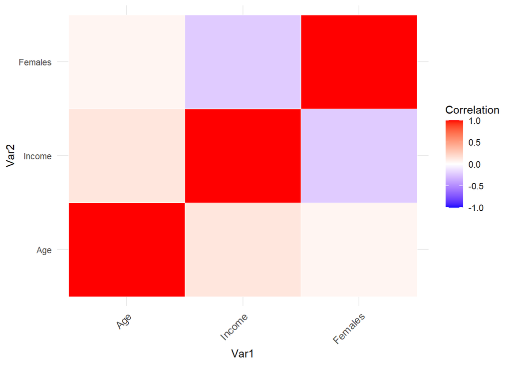

Figure 1.1: Heatmap of Age,Income and females

## 3.2 Income , Marital Status and Ethnicity

[**Violin plots**](https://en.wikipedia.org/wiki/Violin_plot) can be considered as [boxplot](https://en.wikipedia.org/wiki/Box_plot) and [kernel density](https://en.wikipedia.org/wiki/Kernel_density_estimation) , although it shows probability density of the data at different points .Figure 2 represents violin plot of `Income` ,`Marital Status` and `Eth` visualized with (Wickham 2016b)**`ggplot`**, [`geom_violin()`](https://ggplot2.tidyverse.org/reference/geom_violin.html?q=geom_viol#null) and [`aes()`](https://ggplot2.tidyverse.org/reference/) for calling columns. During the 2021 census in England, it was discovered that `Married` households with `Ethnicity` of `Black` had the highest annual income compared to the households who were `Separated` with `Ethnicity` of `Hispanic` discovered to be the lowest. With this we can observe how `Income` varies across different `Marital Status` and `Ethnicity` .

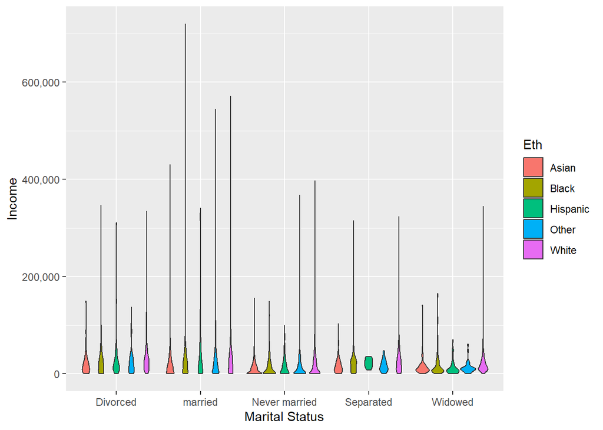

Figure 1.2: Violin plot of Income, Marital status and Ethnicity

## 3.3 Scatter Plot of Ethnicity,Age and Income

**Scatter plot** is sometimes used to draw a prediction or a correlation relationship between variables but for this case we would be introducing a third [**categorical variable**](https://en.wikipedia.org/wiki/Categorical_variable) , `Ethnicity` to two [**numeric variable**](https://www150.statcan.gc.ca/n1/edu/power-pouvoir/ch8/5214817-eng.htm) `Income` and `Age` to indicate where each data point meets .Figure 1.3 shows a [Scatter plot](https://en.wikipedia.org/wiki/Scatter_plot) conducted in (Wickham 2016a)**`ggplot2`** with the aid of a function [**`geom_point()`**](https://plotly.com/ggplot2/geom_point/) to show how `Ethnicity` varies across `Income` and `Age` of the households recorded during the census. `White` people was seen to dominate the chart with the youngest and oldest people recorded while `Black` people was seen to have the highest `Income`.

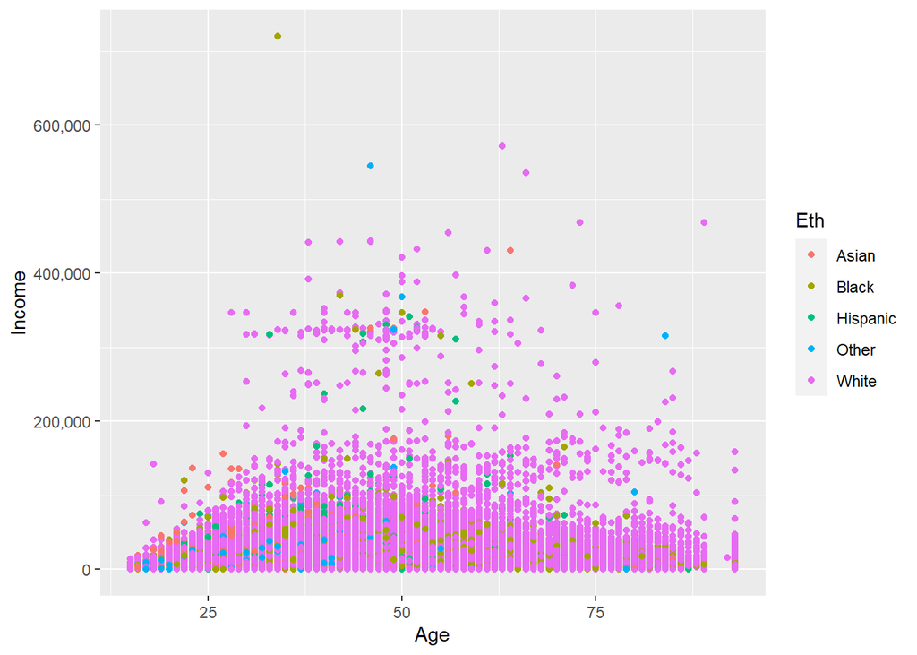

Figure 1.3: Scatter plot of Age, Income and Ethnicity

## 3.4 Distribution of Age Across Ethnicity And Highest Education

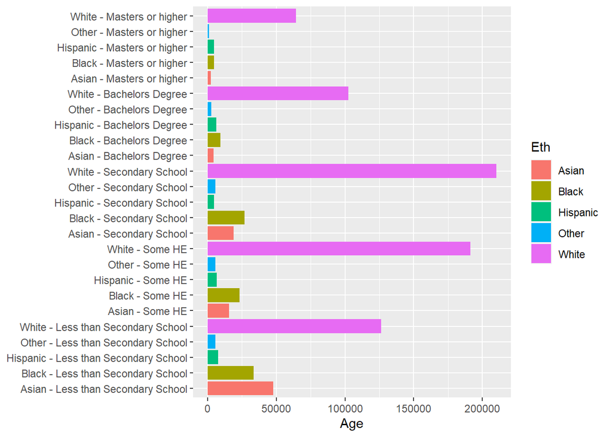

Figure 1.4: Bar chart of Age, Highest Education and Ethnicity

# 4 Conclusion

From the concluded investigation ,It is fair to say that (Wickham et al. 2019)**`tidyverse`** and (Wickham 2016a)**`ggplot`** are essential packages used for visualizing the relationships between variables.we can summarise from the investigation carried out that `Ethnicity` and `Age` clarifies the distributions across other features recorded in the dataset .

## 4.0.1 References

Arnold, Jeffrey B. 2021. “Ggthemes: Extra Themes, Scales and Geoms for ’Ggplot2’.” https://CRAN.R-project.org/package=ggthemes.

Wickham, Hadley. 2016a. “Ggplot2: Elegant Graphics for Data Analysis.” https://ggplot2.tidyverse.org.

———. 2016b. “Ggplot2: Elegant Graphics for Data Analysis.” https://ggplot2.tidyverse.org.

Wickham, Hadley, Mara Averick, Jennifer Bryan, Winston Chang, Lucy D’Agostino McGowan, Romain François, Garrett Grolemund, et al. 2019. “Welcome to the Tidyverse” 4: 1686. https://doi.org/10.21105/joss.01686.

Wickham, Hadley, Romain François, Lionel Henry, Kirill Müller, and Davis Vaughan. 2023. “Dplyr: A Grammar of Data Manipulation.” https://CRAN.R-project.org/package=dplyr.

Wickham, Hadley, Jim Hester, and Jennifer Bryan. 2023. “Readr: Read Rectangular Text Data.” https://CRAN.R-project.org/package=readr.